# Jump Processes Project

## 6.1 Monte-Carlo

```python
def Lambda_t(t, c1, c2, c3, n):
    return c1 + c2 * np.cos(2 * np.pi / n * (t - c3))

def generate_levy_jumps(dt, lambda_jump, jump_size_mean, jump_size_vol, size):
    num_jumps = np.random.poisson(lambda_jump * dt, size=size)
    jump_sizes = np.random.normal(jump_size_mean, jump_size_vol, size=size)
    total_jump = jump_sizes * (num_jumps > 0)
    return total_jump
```

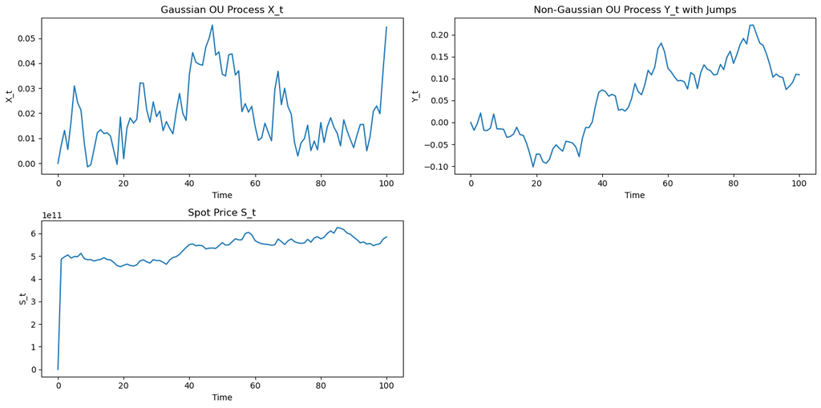

```python
kappa_X = 0.5  # Rate of mean reversion for X
theta_X = 0.0  # Long-term mean for X
sigma_X = 0.1  # Volatility for X

kappa_Y = 0.3  # Rate of mean reversion for Y
theta_Y = 0.0  # Long-term mean for Y
sigma_Y = 0.2  # Volatility for Y
lambda_jump = 0.05  # Jump intensity for Y
jump_size_mean = 0.0  # Mean of jump size for Y
jump_size_vol = 0.1  # Volatility of jump size for Y

# Seasonality parameters
c1, c2, c3, n = 19.14, 3.23, 10.57, 365

# Simulation settings
T = 1.0  # Time horizon
dt = 0.01  # Time step
N = int(T / dt)  # Number of time steps

# Initial conditions
X_0 = 0.0
Y_0 = 0.0
S_0 = 100  # Initial spot price

# Brownian motions
dW_X = np.sqrt(dt) * np.random.randn(N)
dW_Y = np.sqrt(dt) * np.random.randn(N)

# Initialize processes
X_t = np.zeros(N + 1)
Y_t = np.zeros(N + 1)
S_t = np.zeros(N + 1)
X_t[0] = X_0
Y_t[0] = Y_0
S_t[0] = S_0

Y_t = np.zeros(N + 1)
Y_t[0] = Y_0

for t in range(1, N + 1):
    # Gaussian OU process for X
    X_t[t] = X_t[t - 1] + kappa_X * (theta_X - X_t[t - 1]) * dt + sigma_X * dW_X[t - 1]

    # Approximation of Lévy process for Y with jumps
    Y_jump_size = generate_levy_jumps(dt, lambda_jump, jump_size_mean, jump_size_vol, size=1)
    Y_t[t] = Y_t[t - 1] + kappa_Y * (theta_Y - Y_t[t - 1]) * dt + sigma_Y * dW_Y[t - 1] + Y_jump_size

    # Update seasonality for current time step
    current_seasonality = Lambda_t(t * dt, c1, c2, c3, n)

    # Spot price model with seasonality
    S_t[t] = S_0 * np.exp(current_seasonality + X_t[t] + Y_t[t])

# Plot the simulated spot price and components
plt.figure(figsize=(14, 7))

time = range(N+1)
plt.subplot(2, 2, 1)
plt.plot(time, X_t, label='X_t (Gaussian OU)')
plt.title('Gaussian OU Process X_t')
plt.xlabel('Time')
plt.ylabel('X_t')

plt.subplot(2, 2, 2)
plt.plot(time, Y_t, label='Y_t (Non-Gaussian OU with Jumps)')
plt.title('Non-Gaussian OU Process Y_t with Jumps')
plt.xlabel('Time')
plt.ylabel('Y_t')

plt.subplot(2, 2, 3)
plt.plot(time, S_t, label='S_t (Spot Price)')
plt.title('Spot Price S_t')
plt.xlabel('Time')
plt.ylabel('S_t')

plt.tight_layout()
plt.show()
```

The forward price at time $t$ for delivery at time $T$ is given by the expectation under the risk-neutral measure $Q$:

$$ F^Q(t, T) = E^Q\left[\Lambda(T) e^{X_T + Y_T} | \mathcal{F}_t\right] $$

For the Gaussian OU process $X_t$, we have the closed-form solution, well known for OU :

$$ X_T = X_t e^{-\kappa_X(T-t)} + \theta_X(1 - e^{-\kappa_X(T-t)}) + \sigma_X \int_t^T e^{-\kappa_X(T-s)} dB_s^X $$

For the non-Gaussian OU process $Y_t$, we approximate the expected exponential of $Y_t$ by the characteristic function of a Levy Process as we saw it in the article :

$$ E^Q\left[e^{Y_T} | \mathcal{F}_t\right] \approx \phi_{Y_t}(1; T) $$

We use an approximation for the characteristic function $\phi_{Y_t}(u; T)$ based on the Lévy-Khintchine representation:

$$ \phi_{L_t}(u) = \exp\left(T \left(iu\nu - \frac{\sigma^2 u^2}{2} + \int_{\mathbb{R}} (e^{iuz} - 1 - iuz\mathbf{1}_{|z|<1}) \ell(dz) \right)\right) $$

Assuming we can approximate the integral involving the Lévy measure $\ell(dz)$, the forward price approximation can be written as:

$$ F^Q(t, T) = \Lambda(T) \exp\left(\theta_X(1 - e^{-\kappa_X(T-t)}) + m(1 - e^{-\kappa_Y(T-t)})\right) \times \phi_{Y_t}(1; T) $$

```python
def forward_price_with_jumps(S_0, kappa_X, theta_X, sigma_X, kappa_Y, theta_Y, sigma_Y, T, r, Lambda, X_0, Y_0, lambda_jump, mu_jump, sigma_jump):
    OU_X = X_0 * np.exp(-kappa_X * T) + theta_X * (1 - np.exp(-kappa_X * T))
    var_X = sigma_X**2 * (1 - np.exp(-2 * kappa_X * T)) / (2 * kappa_X)

    OU_Y = Y_0 * np.exp(-kappa_Y * T) + theta_Y * (1 - np.exp(-kappa_Y * T))
    var_Y = sigma_Y**2 * (1 - np.exp(-2 * kappa_Y * T)) / (2 * kappa_Y)
    expected_jumps = lambda_jump * T * (mu_jump + 0.5 * sigma_jump**2)

    F_t_T = S_0 * np.exp(-r * T) * Lambda * np.exp(OU_X + OU_Y + expected_jumps + 0.5 * (var_X + var_Y))

    return F_t_T
```

**TEST :**

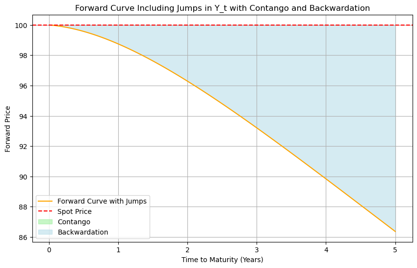

```python
# Parameters
S_0 = 100
r = 0.05
kappa_X = 0.3
theta_X = 0.02
sigma_X = 0.2
kappa_Y = 0.3
theta_Y = 0.01
sigma_Y = 0.15
X_0 = 0.0
Y_0 = 0.0
Lambda = 1  # Assuming constant for simplicity
lambda_jump = 0.1  # Jump intensity for Y
mu_jump = 0.05  # Average jump size for Y
sigma_jump = 0.15  # Jump size volatility for Y

T = np.linspace(0.01, 5, 100)

forward_curve_with_jumps = [forward_price_with_jumps(S_0, kappa_X, theta_X, sigma_X, kappa_Y, theta_Y, sigma_Y, t, r, Lambda, X_0, Y_0, lambda_jump, mu_jump, sigma_jump) for t in T]

plt.figure(figsize=(10, 6))
plt.plot(T, forward_curve_with_jumps, label='Forward Curve with Jumps', color='orange')
plt.axhline(y=S_0, color='red', linestyle='--', label='Spot Price')

plt.fill_between(T, forward_curve_with_jumps, S_0, where=(np.array(forward_curve_with_jumps) > S_0), color='lightgreen', alpha=0.5, label='Contango')
plt.fill_between(T, forward_curve_with_jumps, S_0, where=(np.array(forward_curve_with_jumps) < S_0), color='lightblue', alpha=0.5, label='Backwardation')

plt.title('Forward Curve Including Jumps in Y_t with Contango and Backwardation')
plt.xlabel('Time to Maturity (Years)')
plt.ylabel('Forward Price')
plt.legend()
plt.grid(True)
plt.show()
```

# 7. Calibration

```python
#Market Prices
option_prices_df = pd.DataFrame(columns = ["Strike", 12, 9, 6, 3])
option_prices_df["Strike"] = np.array([95, 96, 97, 98, 99, 100, 101, 102, 103, 104])
option_prices_df[12] = np.array([10.93, 9.55, 8.28, 7.40, 6.86, 6.58, 6.52, 6.49, 6.47, 6.46])
option_prices_df[9] = np.array([11.79, 8.95, 8.07, 7.03, 6.18, 6.04, 5.76, 5.50, 5.50, 5.39])
option_prices_df[6] = np.array([10.71, 8.28, 6.91, 6.36, 5.29, 5.07, 4.76, 4.47, 4.35, 4.14])
option_prices_df[3] = np.array([8.67, 7.14, 5.98, 4.93, 4.09, 3.99, 3.43, 3.01, 2.72, 2.53])
option_prices_df.set_index("Strike", inplace = True)
option_prices_df
```

| Strike | 12 | 9 | 6 | 3 |
| --- | --- | --- | --- | --- |
| 95 | 10.93 | 11.79 | 10.71 | 8.67 |
| 96 | 9.55 | 8.95 | 8.28 | 7.14 |
| 97 | 8.28 | 8.07 | 6.91 | 5.98 |
| 98 | 7.40 | 7.03 | 6.36 | 4.93 |
| 99 | 6.86 | 6.18 | 5.29 | 4.09 |
| 100 | 6.58 | 6.04 | 5.07 | 3.99 |
| 101 | 6.52 | 5.76 | 4.76 | 3.43 |
| 102 | 6.49 | 5.50 | 4.47 | 3.01 |
| 103 | 6.47 | 5.50 | 4.35 | 2.72 |
| 104 | 6.46 | 5.39 | 4.14 | 2.53 |

**Merton**

```python
#Parameters
mu = -0.3
sigma = 0.2
steps = 1000
Nsamples = 100
T = 1
S0 = 100
l = 1
delta = 0.2
r = 0
```

```python
def Merton(Nsamples, steps, mu, sigma, delta, l, r, S0, T):
  """Merton Monte Carlo"""
  np.random.seed(123)
  St = np.ones((Nsamples, steps))*S0
  dt = T/steps
  Nt = np.random.poisson(l*dt, (Nsamples, steps))
  jump = np.random.normal(mu * Nt, np.sqrt(np.abs(Nt)) * np.abs(delta), (Nsamples, steps))
  dWt = np.random.normal(0, 1, (Nsamples, steps))

  compensator = l * (np.exp(mu + delta ** 2 / 2) - 1)

  drift = (r - sigma ** 2 / 2 - compensator) * dt * np.ones((Nsamples, steps))
  diffusion = sigma * dWt * np.sqrt(dt)
  St = S0 * np.exp(np.cumsum(drift + diffusion + jump, axis=1))

  return St
```

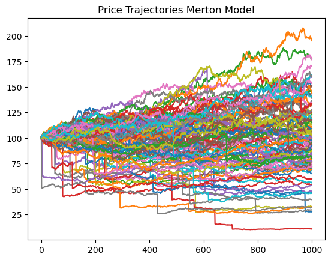

```
the estimated price is: 16.19
```

```python
st = Merton(Nsamples, steps, mu, sigma, delta, l, r, S0, T)
plt.plot(st.T)
plt.title("Price Trajectories Merton Model")
plt.show()

K = 95
T = 1

payoff = np.maximum(st[:, -1] - K, 0)
option_price = np.exp(-r * T) * np.mean(payoff)
print(f"the estimated price is: {option_price:.2f}")
```

**Parameters calibration**

```python
def fonction_objectif_(params, df = option_prices_df, S0 = 100, r = 0, Nsamples = 100, steps = 1000):
  error = 0
  mu, sigma, delta, l = params
  for t in option_prices_df.columns.values:
    for k in df.index.values:
      St = Merton(Nsamples, steps, mu, sigma, delta, l, r, S0, t/12)
      payoff = np.maximum(St[:, -1] - k, 0)
      simulated_price = np.exp(-r * t/12) * np.mean(payoff)

      error +=(simulated_price - df[t].loc[k]) ** 2
  return error
```

```python
params = [-0.1, 0.12, 0.2, 1] #mu, sigma, delta, lamb
fonction_objectif_(params)
```

```
346.5145909256483
```

```python
result = minimize(fonction_objectif_, params, method='Nelder-Mead', tol=1e-6)
result.x
```

```
array([-0.15403453,  0.10948896,  0.07944669,  1.04540468])
```

```python
test = [-0.15403453,  0.10948896,  0.07944669,  1.04540468]
fonction_objectif_(test)
```

```
20.71604013348378
```

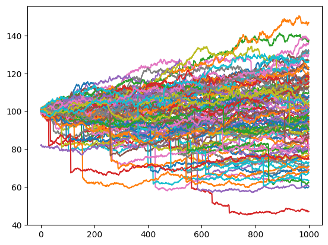

```
Le prix estimé de l'option call européenne est: 7.20
```

```python
S0 = 100
K = 100
T = 1
r = 0

mu = test[0]
sigma = test[1]
delta = test[2]
lamb = test[3]
Nsamples = 100
steps = 1000

St = Merton(Nsamples, steps, mu, sigma, delta, lamb, r, S0, T)
plt.plot(St.T)
plt.show()

payoff = np.maximum(St[:, -1] - K, 0)
option_price = np.exp(-r * T) * np.mean(payoff)
print(f"Le prix estimé de l'option call européenne est: {option_price:.2f}")
```

```python
def CallPrice_Merton_MC(Nsamples, steps, mu, sigma, delta, lamb, r, S0, T, K):
  St = Merton(Nsamples, steps, mu, sigma, delta, lamb, r, S0, T)
  payoff = np.maximum(St[:, -1] - K, 0)
  option_price = np.exp(-r * T) * np.mean(payoff)
  return option_price
```

```python
estimated_prices_Merton_MC_1 = pd.DataFrame(index = option_prices_df.index,
                                columns = option_prices_df.columns)
S0 = 100
r, q = 0, 0
params = [-0.15403453,  0.10948896,  0.07944669,  1.04540468] #[-0.15387704,  0.0590735 ,  0.05821857,  0.99981677] #mu, sigma, delta, lam
Nsamples = 100
steps = 1000

for t in option_prices_df.columns.values:
   for k in option_prices_df.index.values:
    estimated_prices_Merton_MC_1.loc[k, t] = CallPrice_Merton_MC(Nsamples, steps, params[0], params[1], params[2], params[3], r, S0, t/12, k)
#estimated_prices_Merton_MC_1
```

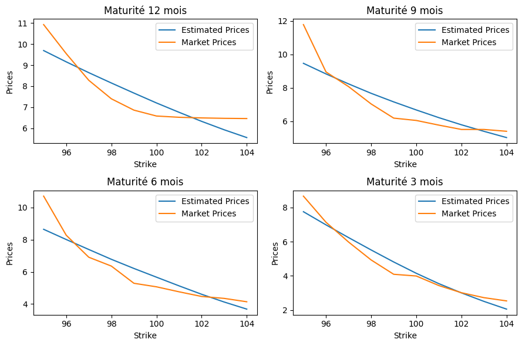

```python
fig, axs = plt.subplots(2, 2, figsize=(9, 6))

axs[0, 0].plot(estimated_prices_Merton_MC_1[12], label = "Estimated Prices")
axs[0, 0].plot(option_prices_df[12], label = "Market Prices")
axs[0, 0].legend()
axs[0, 0].set_title('Maturité 12 mois')

axs[0, 1].plot(estimated_prices_Merton_MC_1[9], label = "Estimated Prices")
axs[0, 1].plot(option_prices_df[9], label = "Market Prices")
axs[0, 1].legend()
axs[0, 1].set_title('Maturité 9 mois')

axs[1, 0].plot(estimated_prices_Merton_MC_1[6], label = "Estimated Prices")
axs[1, 0].plot(option_prices_df[6],label = "Market Prices")
axs[1, 0].legend()
axs[1, 0].set_title('Maturité 6 mois')

axs[1, 1].plot(estimated_prices_Merton_MC_1[3], label = "Estimated Prices")
axs[1, 1].plot(option_prices_df[3], label = "Market Prices")
axs[1, 1].legend()
axs[1, 1].set_title('Maturité 3 mois')

for ax in axs.flat:
    ax.set(xlabel='Strike', ylabel='Prices')

plt.tight_layout()
plt.show()
```

## **Nelder-Mead**

```python
def nelder_mead_optimized(f, start_point, tol=1e-6):
  """Algorithme de Nelder-Mead afin de déterminer les paramètres du modèle PDV minimisant l'erreur entre les prix de modèle et les prix de marché fournis"""

  #Initialisation du simplex
  n = len(start_point)
  simplex = [start_point] + [np.copy(start_point) for _ in range(n)]
  for i in range(1, n + 1):
    simplex[i][i - 1] += 1

  #Applique la fonction au simplexe
  fsimplex = [f(x) for x in simplex]

  cpt = 0
  while True:
    #Tri
    indices = np.argsort(fsimplex)
    simplex = [simplex[i] for i in indices]
    fsimplex = [fsimplex[i] for i in indices]

    #Convergence
    if cpt >= 1000 or np.std(fsimplex) < tol:
      return simplex[0], cpt, np.std(fsimplex)
    cpt += 1

    #Initialisation de x0
    x0 = np.mean(simplex[:-1], axis=0)

    #Réflexion
    xr = x0 + (x0 - simplex[-1])
    fr = f(xr)
    #Conservation de la réflexion
    if fsimplex[0] <= fr < fsimplex[-2]:
      simplex[-1], fsimplex[-1] = xr, fr

    #Etirement
    elif fr < fsimplex[0]:
      xe = x0 + 2 * (x0 - simplex[-1])
      fe = f(xe)
      #Conservation de l'étirement
      if fe < fr:
        simplex[-1], fsimplex[-1] = xe, fe
      else:
        simplex[-1], fsimplex[-1] = xr, fr

    #Contraction
    else:
      #Contraction intérieure
      if fsimplex[-2] <= fr < fsimplex[-1]:
        xc = 0.5 * (x0 + xr)
        fc = f(xc)
        #Conservation de la contraction
        if fc <= fr:
          simplex[-1], fsimplex[-1] = xc, fc

      #Contraction extérieure
      else:
        xc = 0.5 * (x0 + simplex[-1])
        fc = f(xc)
        #Conservation de la contraction
        if fc < fsimplex[-1]:
          simplex[-1], fsimplex[-1] = xc, fc

      #Contraction vers x1
      if fr >= fsimplex[-2]:
        x1 = simplex[0]
        for i in range(1, n + 1):
          simplex[i] = 0.5 * (x1 + simplex[i])
          fsimplex[i] = f(simplex[i])
```

```python
start_point = [0.3, 0.2, 0.2, 1]
nelder_mead_optimized(fonction_objectif_, start_point, tol=1e-6)
```

```
(array([-0.12853528, -0.10846058,  0.13013685,  1.56573513]),
 134,
 1.910526656081706e-07)
```

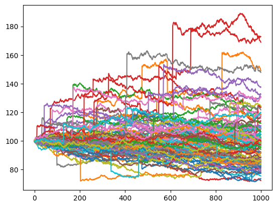

```
Le prix estimé de l'option call européenne est: 7.16
```

```python
param = [0.07159637, 0.09601369, 0.11451991, 1.39064455]
S0 = 100
K = 100
T = 1
r = 0

mu = param[0]
sigma = param[1]
delta = param[2]
lamb = param[3]
Nsamples = 100
steps = 1000

St = Merton(Nsamples, steps, mu, sigma, delta, lamb, r, S0, T)
plt.plot(St.T)
plt.show()

payoff = np.maximum(St[:, -1] - K, 0)

option_price = np.exp(-r * T) * np.mean(payoff)

print(f"Le prix estimé de l'option call européenne est: {option_price:.2f}")
```

```python
estimated_prices_Merton_NM = pd.DataFrame(index = option_prices_df.index,
                                columns = option_prices_df.columns)
S0 = 100
r, q = 0, 0
params = [0.07159637, 0.09601369, 0.11451991, 1.39064455] #mu, sigma, delta, lambda
Nsamples = 100
steps = 1000

for t in option_prices_df.columns.values:
   for k in option_prices_df.index.values:
    estimated_prices_Merton_NM.loc[k, t] = CallPrice_Merton_MC(Nsamples, steps, params[0], params[1], params[2], params[3], r, S0, t/12, k)
#estimated_prices_Merton_NM
```

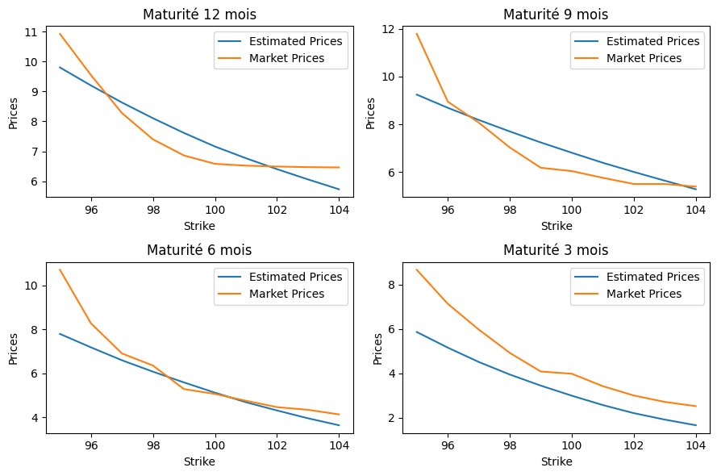

```python
fig, axs = plt.subplots(2, 2, figsize=(9, 6))

axs[0, 0].plot(estimated_prices_Merton_NM[12], label = "Estimated Prices")
axs[0, 0].plot(option_prices_df[12], label = "Market Prices")
axs[0, 0].legend()
axs[0, 0].set_title('Maturité 12 mois')

axs[0, 1].plot(estimated_prices_Merton_NM[9], label = "Estimated Prices")
axs[0, 1].plot(option_prices_df[9], label = "Market Prices")
axs[0, 1].legend()
axs[0, 1].set_title('Maturité 9 mois')

axs[1, 0].plot(estimated_prices_Merton_NM[6], label = "Estimated Prices")
axs[1, 0].plot(option_prices_df[6],label = "Market Prices")
axs[1, 0].legend()
axs[1, 0].set_title('Maturité 6 mois')

axs[1, 1].plot(estimated_prices_Merton_NM[3], label = "Estimated Prices")
axs[1, 1].plot(option_prices_df[3], label = "Market Prices")
axs[1, 1].legend()
axs[1, 1].set_title('Maturité 3 mois')

for ax in axs.flat:
    ax.set(xlabel='Strike', ylabel='Prices')

plt.tight_layout()
plt.show()
```

## **Modèle de Merton Lewis**

```python
def merton(params, z):
  """Fonction caractéristique"""
  sigma, lam, mu, delta = params
  return lam * (np.exp(1j * z * mu - 0.5 * delta**2 * z**2) - 1) -0.5 * (z**2) * sigma**2
```

```python
def characteristic_function(z, S0, T, r, q, params):
  ce = T * merton(params, z) - 1j * z * merton(params, -1j)
  cf = np.exp(1j * z * (np.log(S0) + T * (r - q)) + ce)
  return cf
```

```python
def CallPricingLewis(S0, K, T, r, q, params, trunc, im):
  def integrand(om, S0, K, T, r, q, params, im):
    i = 1j
    z = om + i * im
    return characteristic_function(-z, S0, T, r, q, params) * K ** (1 + i * z) / (i * z - z ** 2)

  # Use quad for numerical integration
  call, _ = si.integrate.quad(integrand, -trunc, trunc, args=(S0, K, T, r, q, params, im))

  call *= 0.5 * np.exp(-r * T) / np.pi
  call = abs(call)

  return call
```

```python
S0 = 100
K = 95
T = 1
r, q = 0, 0
params = [0.0590735, 0.99981677, -0.15387704, 0.05821857] #sigma, lam, mu, delta
trunc = 5
im = 3
CallPricingLewis(S0, K, T, r, q, params, trunc, im)
```

```
9.081680914425334
```

**Calibration des paramètres**

```python
def fonction_objectif_lewis(params, df = option_prices_df, S0 = 100, r = 0, q = 0, trunc = 5, im = 3):
  error = 0
  sigma, lam, mu, delta = params
  for t in option_prices_df.columns.values:
    for k in df.index.values:
      St = CallPricingLewis(S0, k, t/12, r, q, params, trunc, im)
      simulated_price = np.exp(-r * t/12) * St

      error +=(simulated_price - df[t].loc[k]) ** 2
  return error
```

```python
bounds = ((0, None), (0, None), (None, None), (0, None))
result = minimize(fonction_objectif_lewis, params, method='Nelder-Mead', bounds = bounds, tol=1e-6)
result.x
```

```
array([1.75626566e-01, 4.99978517e+00, 3.20410562e-03, 0.00000000e+00])
```

```python
S0 = 100
K = 104
T = 3/12
r, q = 0, 0
trunc = 5
im = 3
params = [0.175626566, 4.99978517, 3.20410562e-03, 0.0]
CallPricingLewis(S0, K, T, r, q, params, trunc, im)
```

```
3.715320324492325
```

```python
estimated_prices_Merton_Lewis = pd.DataFrame(index = option_prices_df.index,
                                columns = option_prices_df.columns)
S0 = 100
r, q = 0, 0
params = [0.175626566, 4.99978517, 3.20410562e-03, 0.0] #sigma, lam, mu, delta
trunc = 5
im = 3

for t in option_prices_df.columns.values:
   for k in option_prices_df.index.values:
    estimated_prices_Merton_Lewis.loc[k, t] = CallPricingLewis(S0, k, t/12, r, q, params, trunc, im)
#estimated_prices_Merton_Lewis
```

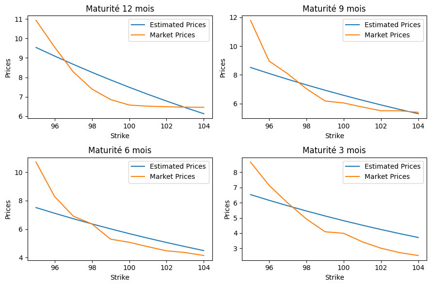

```python
fig, axs = plt.subplots(2, 2, figsize=(9, 6))

axs[0, 0].plot(estimated_prices_Merton_Lewis[12], label = "Estimated Prices")
axs[0, 0].plot(option_prices_df[12], label = "Market Prices")
axs[0, 0].legend()
axs[0, 0].set_title('Maturité 12 mois')

axs[0, 1].plot(estimated_prices_Merton_Lewis[9], label = "Estimated Prices")
axs[0, 1].plot(option_prices_df[9], label = "Market Prices")
axs[0, 1].legend()
axs[0, 1].set_title('Maturité 9 mois')

axs[1, 0].plot(estimated_prices_Merton_Lewis[6], label = "Estimated Prices")
axs[1, 0].plot(option_prices_df[6],label = "Market Prices")
axs[1, 0].legend()
axs[1, 0].set_title('Maturité 6 mois')

axs[1, 1].plot(estimated_prices_Merton_Lewis[3], label = "Estimated Prices")
axs[1, 1].plot(option_prices_df[3], label = "Market Prices")
axs[1, 1].legend()
axs[1, 1].set_title('Maturité 3 mois')

for ax in axs.flat:
    ax.set(xlabel='Strike', ylabel='Prices')

plt.tight_layout()
plt.show()
```

## **Modèle NIG MC**

```python
def IG(mu, lam, size):
    v = np.random.normal(0, 1, size)
    y = v**2
    x = mu + (mu**2 * y) / (2 * lam) - (mu / (2 * lam)) * np.sqrt(4 * mu * lam * y + mu**2 * y**2)
    test = np.random.uniform(0, 1, size)
    x = np.where(test <= (mu / (mu + x)), x, (mu**2) / x)
    return x
```

```python
def inverse_gaussian(mu, lam, Nsamples, steps):
  v = np.random.normal(0, 1, (Nsamples, steps))
  y = v ** 2
  x = mu + (mu ** 2 * y) / (2 * lam) - (mu / (2 * lam)) * np.sqrt(np.abs(4 * mu * lam * y + mu ** 2 * y ** 2))
  z = np.random.uniform(0, 1, (Nsamples, steps))

  x = np.where(z <= (mu / (mu + x)), x, (mu**2) / x)
  return x
```

```python
def NIG(Nsamples, steps, S0, T, r, q, kappa, sigma, theta):
  np.random.seed(123)
  dt = T/steps
  St = np.ones((Nsamples, steps+1))*S0
  dW = np.random.normal(0, 1, (Nsamples, steps))
  compensator = (1 - np.sqrt(1 - sigma **2 * kappa - 2 * theta * kappa)) / kappa
  l = (dt**2)/kappa
  RV = np.cumsum(inverse_gaussian(dt, l, Nsamples, steps), axis = 1)
  increment = (r - q - compensator) * dt + theta * RV + sigma * dW * np.sqrt(RV)
  St[: , 1:] = S0 * np.exp(np.cumsum(increment, axis=1))

  return St
```

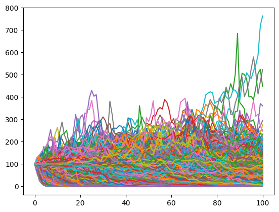

```
Le prix estimé de l'option call européenne est: 1.18
```

```python
param = [1.5, 0.2, -0.1] #kappa, sigma, theta
S0 = 100
K = 100
T = 1
r, q = 0, 0

kappa = param[0]
sigma = param[1]
theta = param[2]
Nsamples = 10000
steps = 100

St = NIG(Nsamples, steps, S0, T, r, q, kappa, sigma, theta)
plt.plot(St.T)
plt.show()

payoff = np.maximum(St[:, -1] - K, 0)

option_price = np.exp(-r * T) * np.mean(payoff)

print(f"Le prix estimé de l'option call européenne est: {option_price:.2f}")
```

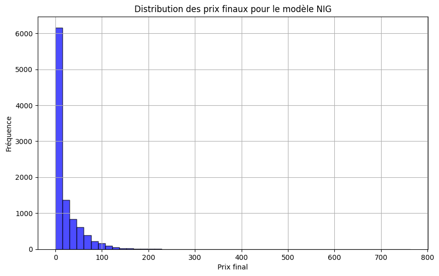

```python
final_prices = St[:, -1]
plt.figure(figsize=(10, 6))
plt.hist(final_prices, bins=50, alpha=0.7, color='blue', edgecolor='black')
plt.title('Distribution des prix finaux pour le modèle NIG')
plt.xlabel('Prix final')
plt.ylabel('Fréquence')
plt.grid(True)
plt.show()
```

**Parameters Calibration**

```python
def fonction_objectif_NIG_(params, df = option_prices_df, S0 = 100, r = 0, q = 0, Nsamples = 10000, steps = 10):
  error = 0
  kappa, sigma, theta = params
  for t in option_prices_df.columns.values:
    for k in df.index.values:
      St = NIG(Nsamples, steps, S0, t/12, r, q, kappa, sigma, theta)
      payoff = np.maximum(St[:, -1] - k, 0)
      simulated_price = np.exp(-r * t/12) * np.mean(payoff)

      error +=(simulated_price - df[t].loc[k]) ** 2
  return error
```

```python
params = [0.25, 0.1, -0.1]
fonction_objectif_NIG_(params)
```

```
1267.8362364069728
```

```python
bounds = ((0, None), (0, None), (None, None))
result = minimize(fonction_objectif_NIG_, params, method='Nelder-Mead', bounds = bounds, tol=1e-6)
result.x
```

```
array([ 0.45329616,  0.10185062, -0.01141293])
```

```python
params = [0.45329616, 0.10185062, -0.01141293]
fonction_objectif_NIG_(params)
```

```
28.383118600198504
```

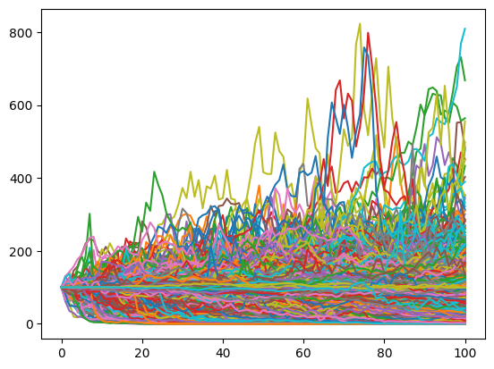

```
Le prix estimé de l'option call européenne est: 7.43
```

```python
params = [2.44921932,  0.15585054, -0.03634918]
Nsamples = 10000
steps = 100
S0 = 100
T = 6/12
r, q = 0, 0
K = 99

kappa = params[0]
sigma = params[1]
theta = params[2]
St = NIG(Nsamples, steps, S0, T, r, q, kappa, sigma, theta)
plt.plot(St.T)
plt.show()

payoff = np.maximum(St[:, -1] - K, 0)
option_price = np.exp(-r * T) * np.mean(payoff)
print(f"Le prix estimé de l'option call européenne est: {option_price:.2f}")
```

```python
def CallPrice_NIG_MC(Nsamples, steps, S0, T, r, q, kappa, sigma, theta, K):
  St = NIG(Nsamples, steps, S0, T, r, q, kappa, sigma, theta)
  payoff = np.maximum(St[:, -1] - K, 0)
  option_price = np.exp(-r * T) * np.mean(payoff)
  return option_price
```

```python
estimated_prices_NIG_MC = pd.DataFrame(index = option_prices_df.index,
                                columns = option_prices_df.columns)
S0 = 100
r, q = 0, 0
params = [0.45329616, 0.10185062, -0.01141293] #[2.44921932,  0.15585054, -0.03634918] #kappa, sigma, theta
Nsamples = 10000
steps = 10

for t in option_prices_df.columns.values:
   for k in option_prices_df.index.values:
    estimated_prices_NIG_MC.loc[k, t] = CallPrice_NIG_MC(Nsamples, steps, S0, t/12, r, q, params[0], params[1], params[2], k)
#estimated_prices_NIG_MC
```

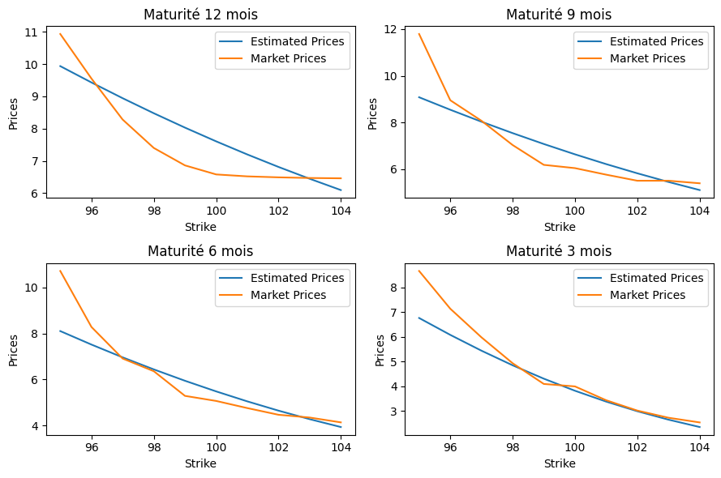

```python
fig, axs = plt.subplots(2, 2, figsize=(9, 6))

axs[0, 0].plot(estimated_prices_NIG_MC[12], label = "Estimated Prices")
axs[0, 0].plot(option_prices_df[12], label = "Market Prices")
axs[0, 0].legend()
axs[0, 0].set_title('Maturité 12 mois')

axs[0, 1].plot(estimated_prices_NIG_MC[9], label = "Estimated Prices")
axs[0, 1].plot(option_prices_df[9], label = "Market Prices")
axs[0, 1].legend()
axs[0, 1].set_title('Maturité 9 mois')

axs[1, 0].plot(estimated_prices_NIG_MC[6], label = "Estimated Prices")
axs[1, 0].plot(option_prices_df[6],label = "Market Prices")
axs[1, 0].legend()
axs[1, 0].set_title('Maturité 6 mois')

axs[1, 1].plot(estimated_prices_NIG_MC[3], label = "Estimated Prices")
axs[1, 1].plot(option_prices_df[3], label = "Market Prices")
axs[1, 1].legend()
axs[1, 1].set_title('Maturité 3 mois')

for ax in axs.flat:
    ax.set(xlabel='Strike', ylabel='Prices')

plt.tight_layout()
plt.show()
```

**Modèle NIG Lewis**

```python
def nig(params, z):
  kappa, sigma, mu = params
  return (1 - np.sqrt(1 + z**2 * sigma**2 * kappa - 2 * 1j * mu * z * kappa)) / kappa
```

```python
def characteristic_function(z, S0, T, r, q, params):
  ce = T * nig(params, z) - 1j * z * nig(params, -1j)
  cf = np.exp(1j * z * (np.log(S0) + T * (r - q)) + ce)
  return cf
```

```python
def CallPricingLewis_NIG(S0, K, T, r, q, params, trunc, im):
  def integrand(om, S0, K, T, r, q, params, im):
    i = 1j
    z = om + i * im
    return characteristic_function(-z, S0, T, r, q, params) * K ** (1 + i * z) / (i * z - z ** 2)

  # Use quad for numerical integration
  call, _ = si.integrate.quad(integrand, -trunc, trunc, args=(S0, K, T, r, q, params, im))

  call *= 0.5 * np.exp(-r * T) / np.pi
  call = abs(call)

  return call
```

```python
S0 = 100
K = 95
T = 1
r, q = 0, 0
params = [1.58697696, 0.23037561, -0.07559086] #kappa, sigma, mu
trunc = 5
im = 3
CallPricingLewis_NIG(S0, K, T, r, q, params, trunc, im)
```

```
10.729796079736637
```

**Parameters Calibration**

```python
def fonction_objectif_NIG_lewis(params, df = option_prices_df, S0 = 100, r = 0, q = 0, trunc = 5, im = 3):
  error = 0
  kappa, sigma, mu = params
  for t in option_prices_df.columns.values:
    for k in df.index.values:
      St = CallPricingLewis_NIG(S0, k, t/12, r, q, params, trunc, im)
      simulated_price = np.exp(-r * t) * St

      error +=(simulated_price - df[t].loc[k]) ** 2
  return error
```

```python
params = [0.25, 0.1, -0.1] #kappa, sigma, mu
fonction_objectif_NIG_lewis(params)
```

```
262.00145528414146
```

```python
bounds = ((0, None), (None, None), (None, None))
result = minimize(fonction_objectif_NIG_lewis, params, method='Nelder-Mead', bounds = bounds, tol=1e-6)
result.x
```

```
array([1.78855321e-08, 1.75774672e-01, 1.60153619e-02])
```

```python
params = [1.78855321e-08, 1.75774672e-01, 1.60153619e-02] #kappa, sigma, mu
fonction_objectif_NIG_lewis(params)
```

```
45.21164474455553
```

```python
S0 = 100
K = 99
T = 1
r, q = 0, 0
params = [3.96902983e-08, 1.75778655e-01, 1.60183547e-02] #kappa, sigma, mu
trunc = 5
im = 3
CallPricingLewis_NIG(S0, K, T, r, q, params, trunc, im)
```

```
7.868526885638517
```

**Plot**

```python
estimated_prices_NIG_Lewis = pd.DataFrame(index = option_prices_df.index,
                                columns = option_prices_df.columns)
S0 = 100
r, q = 0, 0
params = [1.78855321e-08, 1.75774672e-01, 1.60153619e-02] #kappa, sigma, mu
trunc = 5
im = 3

for t in option_prices_df.columns.values:
   for k in option_prices_df.index.values:
    estimated_prices_NIG_Lewis.loc[k, t] = CallPricingLewis_NIG(S0, k, t/12, r, q, params, trunc, im)
#estimated_prices_NIG_Lewis
```

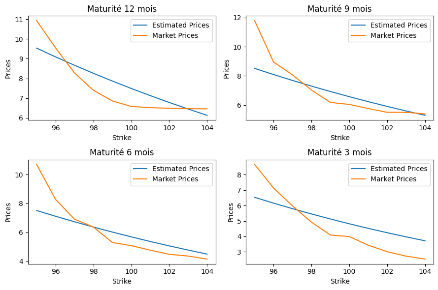

```python
fig, axs = plt.subplots(2, 2, figsize=(9, 6))

axs[0, 0].plot(estimated_prices_NIG_Lewis[12], label = "Estimated Prices")
axs[0, 0].plot(option_prices_df[12], label = "Market Prices")
axs[0, 0].legend()
axs[0, 0].set_title('Maturité 12 mois')

axs[0, 1].plot(estimated_prices_NIG_Lewis[9], label = "Estimated Prices")
axs[0, 1].plot(option_prices_df[9], label = "Market Prices")
axs[0, 1].legend()
axs[0, 1].set_title('Maturité 9 mois')

axs[1, 0].plot(estimated_prices_NIG_Lewis[6], label = "Estimated Prices")
axs[1, 0].plot(option_prices_df[6],label = "Market Prices")
axs[1, 0].legend()
axs[1, 0].set_title('Maturité 6 mois')

axs[1, 1].plot(estimated_prices_NIG_Lewis[3], label = "Estimated Prices")
axs[1, 1].plot(option_prices_df[3], label = "Market Prices")
axs[1, 1].legend()
axs[1, 1].set_title('Maturité 3 mois')

for ax in axs.flat:
    ax.set(xlabel='Strike', ylabel='Prices')

plt.tight_layout()
plt.show()
```

**Test with stochastic algorithm to avoid local minimum**

```python
!pip install pyswarm
from pyswarm import pso
```

```python
low = [0, 0, -0.1]  #kappa, sigma, mu
up = [0.2, 0.2, 0.1]  #kappa, sigma, mu

xopt, fopt = pso(fonction_objectif_NIG_lewis, low, up)

print("Les paramètres optimisés sont:", xopt)
print("L'erreur minimale est:", fopt)
```

```
Stopping search: Swarm best objective change less than 1e-08
Les paramètres optimisés sont: [3.58763228e-06 1.75397731e-01 1.59431226e-02]
L'erreur minimale est: 45.21311214572731
```

```python
params = [3.58763228e-06, 1.75397731e-01, 1.59431226e-02] #kappa, sigma, mu
fonction_objectif_NIG_lewis(params)
```

```
45.21311214929723
```

```python
estimated_prices_NIG_Lewis_2 = pd.DataFrame(index = option_prices_df.index,
                                columns = option_prices_df.columns)
S0 = 100
r, q = 0, 0
params = [3.58763228e-06, 1.75397731e-01, 1.59431226e-02] #kappa, sigma, mu
trunc = 5
im = 3

for t in option_prices_df.columns.values:
   for k in option_prices_df.index.values:
    estimated_prices_NIG_Lewis_2.loc[k, t] = CallPricingLewis_NIG(S0, k, t/12, r, q, params, trunc, im)
estimated_prices_NIG_Lewis_2
```

| Strike | 12 | 9 | 6 | 3 |
| --- | --- | --- | --- | --- |
| 95 | 9.525334 | 8.506353 | 7.508942 | 6.536505 |
| 96 | 9.083226 | 8.084844 | 7.109358 | 6.160127 |
| 97 | 8.658381 | 7.680657 | 6.727084 | 5.800971 |
| 98 | 8.250247 | 7.293203 | 6.361497 | 5.458382 |
| 99 | 7.85828 | 6.921908 | 6.01199 | 5.131721 |
| 100 | 7.481949 | 6.566206 | 5.677969 | 4.820369 |
| 101 | 7.12073 | 6.225549 | 5.358859 | 4.523723 |
| 102 | 6.774115 | 5.899399 | 5.054096 | 4.2412 |
| 103 | 6.441602 | 5.587232 | 4.763136 | 3.972231 |
| 104 | 6.122704 | 5.28854 | 4.485447 | 3.716269 |

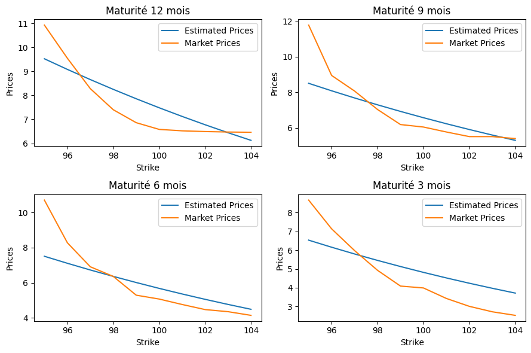

```python
fig, axs = plt.subplots(2, 2, figsize=(9, 6))

axs[0, 0].plot(estimated_prices_NIG_Lewis_2[12], label = "Estimated Prices")
axs[0, 0].plot(option_prices_df[12], label = "Market Prices")
axs[0, 0].legend()
axs[0, 0].set_title('Maturité 12 mois')

axs[0, 1].plot(estimated_prices_NIG_Lewis_2[9], label = "Estimated Prices")
axs[0, 1].plot(option_prices_df[9], label = "Market Prices")
axs[0, 1].legend()
axs[0, 1].set_title('Maturité 9 mois')

axs[1, 0].plot(estimated_prices_NIG_Lewis_2[6], label = "Estimated Prices")
axs[1, 0].plot(option_prices_df[6],label = "Market Prices")
axs[1, 0].legend()
axs[1, 0].set_title('Maturité 6 mois')

axs[1, 1].plot(estimated_prices_NIG_Lewis_2[3], label = "Estimated Prices")
axs[1, 1].plot(option_prices_df[3], label = "Market Prices")
axs[1, 1].legend()
axs[1, 1].set_title('Maturité 3 mois')

for ax in axs.flat:
    ax.set(xlabel='Strike', ylabel='Prices')

plt.tight_layout()
plt.show()
```

```python
def fonction_objectif_NIG_lewis2(params, sigma = 1.75397731e-01, df = option_prices_df, S0 = 100, r = 0, q = 0, trunc = 5, im = 3):
  error = 0
  params = [kappa, sigma, mu]
  for t in option_prices_df.columns.values:
    for k in df.index.values:
      St = CallPricingLewis_NIG(S0, k, t/12, r, q, params, trunc, im)
      simulated_price = np.exp(-r * t) * St

      error +=(simulated_price - df[t].loc[k]) ** 2
  return error
```

```python
params = [0.2, 1.75397731e-01, 0.1]
fonction_objectif_NIG_lewis2(params)
```

```
74.95733855179732
```

```python
low = [0, -0.1]  #kappa, mu
up = [1, 0.1]  #kappa, mu

xopt, fopt = pso(fonction_objectif_NIG_lewis2, low, up)

print("Les paramètres optimisés sont:", xopt)
print("L'erreur minimale est:", fopt)
```

```
Stopping search: maximum iterations reached --> 100
Les paramètres optimisés sont: [0.92494352 0.08829462]
L'erreur minimale est: 74.95733855179732
```

```python
estimated_prices_NIG_Lewis_3 = pd.DataFrame(index = option_prices_df.index,
                                columns = option_prices_df.columns)
S0 = 100
r, q = 0, 0
params = [0.92494352, 1.75397731e-01, 0.08829462] #kappa, sigma, mu
trunc = 5
im = 3

for t in option_prices_df.columns.values:
   for k in option_prices_df.index.values:
    estimated_prices_NIG_Lewis_3.loc[k, t] = CallPricingLewis_NIG(S0, k, t/12, r, q, params, trunc, im)
estimated_prices_NIG_Lewis_3
```

| Strike | 12 | 9 | 6 | 3 |
| --- | --- | --- | --- | --- |
| 95 | 10.449891 | 8.340978 | 6.400406 | 4.633584 |
| 96 | 10.030309 | 7.965695 | 6.070622 | 4.350074 |
| 97 | 9.626532 | 7.605824 | 5.755693 | 4.080697 |
| 98 | 9.238042 | 7.260811 | 5.455035 | 3.824846 |
| 99 | 8.864333 | 6.930119 | 5.168085 | 3.581939 |
| 100 | 8.504908 | 6.613222 | 4.894296 | 3.351411 |
| 101 | 8.159285 | 6.309612 | 4.633138 | 3.132721 |
| 102 | 7.82699 | 6.018792 | 4.384097 | 2.925345 |
| 103 | 7.507563 | 5.740282 | 4.146679 | 2.728778 |
| 104 | 7.200556 | 5.473615 | 3.920405 | 2.542537 |

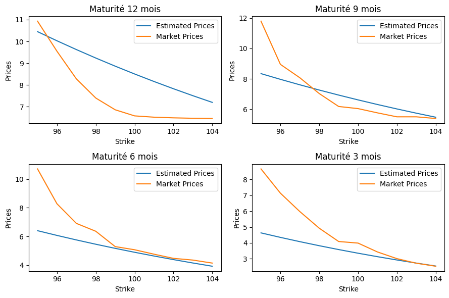

```python
fig, axs = plt.subplots(2, 2, figsize=(9, 6))

axs[0, 0].plot(estimated_prices_NIG_Lewis_3[12], label = "Estimated Prices")
axs[0, 0].plot(option_prices_df[12], label = "Market Prices")
axs[0, 0].legend()
axs[0, 0].set_title('Maturité 12 mois')

axs[0, 1].plot(estimated_prices_NIG_Lewis_3[9], label = "Estimated Prices")
axs[0, 1].plot(option_prices_df[9], label = "Market Prices")
axs[0, 1].legend()
axs[0, 1].set_title('Maturité 9 mois')

axs[1, 0].plot(estimated_prices_NIG_Lewis_3[6], label = "Estimated Prices")
axs[1, 0].plot(option_prices_df[6],label = "Market Prices")
axs[1, 0].legend()
axs[1, 0].set_title('Maturité 6 mois')

axs[1, 1].plot(estimated_prices_NIG_Lewis_3[3], label = "Estimated Prices")
axs[1, 1].plot(option_prices_df[3], label = "Market Prices")
axs[1, 1].legend()
axs[1, 1].set_title('Maturité 3 mois')

for ax in axs.flat:
    ax.set(xlabel='Strike', ylabel='Prices')

plt.tight_layout()
plt.show()
```

La calibration ne semble pas fonctionner pour la maturité 1 an mais les prix sont moeux estimés pour les maturités 3, 6 et 9 mois

**CGMY Lewis**

```python
def cgmy(params, z):
  C, G, M, Y = params
  return C * si.special.gamma(-Y) * ((M - 1j * z) ** Y - M ** Y + (G + 1j * z) ** Y - G ** Y)
```

```python
def characteristic_function_CGMY(z, S0, T, r, q, params):
  ce = T * cgmy(params, z) - 1j * z * cgmy(params, -1j)
  cf = np.exp(1j * z * (np.log(S0) + T * (r - q)) + ce)
  return cf
```

```python
def CallPricingLewis_CGMY(S0, K, T, r, q, params, trunc, im):
  def integrand(om, S0, K, T, r, q, params, im):
    i = 1j
    z = om + i * im
    return characteristic_function_CGMY(-z, S0, T, r, q, params) * K ** (1 + i * z) / (i * z - z ** 2)

  # Use quad for numerical integration
  call, _ = si.integrate.quad(integrand, -trunc, trunc, args=(S0, K, T, r, q, params, im))

  call *= 0.5 * np.exp(-r * T) / np.pi
  call = abs(call)

  return call
```

```python
S0 = 100
K = 95
T = 1
r, q = 0, 0
params = [0.004, 0.5, 0.5, 1.5] #C, G, M, Y
trunc = 5
im = 3
CallPricingLewis_CGMY(S0, K, T, r, q, params, trunc, im)
```

```
7.695423543377208
```

**Parameters Calibration**

```python
def fonction_objectif_CGMY_lewis(params, df = option_prices_df, S0 = 100, r = 0, q = 0, trunc = 5, im = 3):
  error = 0
  C, G, M, Y = params
  for t in option_prices_df.columns.values:
    for k in option_prices_df.index.values:
      St = CallPricingLewis_CGMY(S0, k, t/12, r, q, params, trunc, im)
      simulated_price = np.exp(-r * t) * St

      error +=(simulated_price - df[t].loc[k]) ** 2
  return error
```

```python
params = [0.08, 2, 2, 1.5] #C, G, M, Y
fonction_objectif_CGMY_lewis(params)
```

```
1387.858453070181
```

```python
bounds = ((0, None), (0, None), (0, None), (0, 2))
result = minimize(fonction_objectif_CGMY_lewis, params, method='Nelder-Mead', bounds = bounds, tol = 1e-6)
result.x
```

```
array([  0.23559032, 149.25489632, 148.21722302,   1.38127822])
```

```python
type(result.x)
```

```
numpy.ndarray
```

```python
S0 = 100
K = 103
T = 6/12
r, q = 0, 0
params = [  0.23559032, 149.25489632, 148.21722302,   1.38127822] #[2.00467074e+01, 1.64699185e+03, 1.64595537e+03, 1.02972640] #C, G, M, Y
trunc = 5
im = 3
CallPricingLewis_CGMY(S0, K, T, r, q, params, trunc, im)
```

```
4.7650503288136585
```

```python
option_prices_df
```

| Strike | 12 | 9 | 6 | 3 |
| --- | --- | --- | --- | --- |
| 95 | 10.93 | 11.79 | 10.71 | 8.67 |
| 96 | 9.55 | 8.95 | 8.28 | 7.14 |
| 97 | 8.28 | 8.07 | 6.91 | 5.98 |
| 98 | 7.40 | 7.03 | 6.36 | 4.93 |
| 99 | 6.86 | 6.18 | 5.29 | 4.09 |
| 100 | 6.58 | 6.04 | 5.07 | 3.99 |
| 101 | 6.52 | 5.76 | 4.76 | 3.43 |
| 102 | 6.49 | 5.50 | 4.47 | 3.01 |
| 103 | 6.47 | 5.50 | 4.35 | 2.72 |
| 104 | 6.46 | 5.39 | 4.14 | 2.53 |

**Plot**

```python
estimated_prices_CGMY_Lewis = pd.DataFrame(index = option_prices_df.index,
                                columns = option_prices_df.columns)
S0 = 100
r, q = 0, 0
params = [2.00467074e+01, 1.64699185e+03, 1.64595537e+03, 1.02972640] #C, G, M, Y
trunc = 5
im = 3

for t in option_prices_df.columns.values:
   for k in option_prices_df.index.values:
    estimated_prices_CGMY_Lewis.loc[k, t] = CallPricingLewis_CGMY(S0, k, t/12, r, q, params, trunc, im)
estimated_prices_CGMY_Lewis
```

| Strike | 12 | 9 | 6 | 3 |
| --- | --- | --- | --- | --- |
| 95 | 9.535947 | 8.512694 | 7.511169 | 6.534816 |
| 96 | 9.093722 | 8.091138 | 7.111618 | 6.158561 |
| 97 | 8.668754 | 7.686898 | 6.729371 | 5.799523 |
| 98 | 8.260491 | 7.299386 | 6.363806 | 5.457046 |
| 99 | 7.868391 | 6.928027 | 6.014317 | 5.130492 |
| 100 | 7.49192 | 6.572258 | 5.680309 | 4.819241 |
| 101 | 7.130559 | 6.23153 | 5.361207 | 4.522692 |
| 102 | 6.783796 | 5.905304 | 5.056449 | 4.24026 |
| 103 | 6.451133 | 5.59306 | 4.76549 | 3.971379 |
| 104 | 6.132082 | 5.294286 | 4.487799 | 3.7155 |

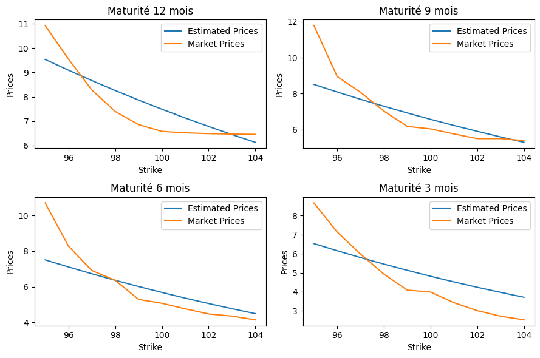

```python
fig, axs = plt.subplots(2, 2, figsize=(9, 6))

axs[0, 0].plot(estimated_prices_CGMY_Lewis[12], label = "Estimated Prices")
axs[0, 0].plot(option_prices_df[12], label = "Market Prices")
axs[0, 0].legend()
axs[0, 0].set_title('Maturité 12 mois')

axs[0, 1].plot(estimated_prices_CGMY_Lewis[9], label = "Estimated Prices")
axs[0, 1].plot(option_prices_df[9], label = "Market Prices")
axs[0, 1].legend()
axs[0, 1].set_title('Maturité 9 mois')

axs[1, 0].plot(estimated_prices_CGMY_Lewis[6], label = "Estimated Prices")
axs[1, 0].plot(option_prices_df[6],label = "Market Prices")
axs[1, 0].legend()
axs[1, 0].set_title('Maturité 6 mois')

axs[1, 1].plot(estimated_prices_CGMY_Lewis[3], label = "Estimated Prices")
axs[1, 1].plot(option_prices_df[3], label = "Market Prices")
axs[1, 1].legend()
axs[1, 1].set_title('Maturité 3 mois')

for ax in axs.flat:
    ax.set(xlabel='Strike', ylabel='Prices')

plt.tight_layout()
plt.show()
```

**Conclusion**

The NIG model seems to have a systematic problem with option price estimation, underestimating In-The-Money (ITM) options and overestimating OTM options, which could indicate that the model does not correctly capture the return distribution of the underlying asset. The same observation applies to the CGMY model.

For the NIG model, adjusting the skewness and kurtosis parameters could improve price estimates for longer maturities.